# cloudstoR

[figure not shown]

The goal of `cloudstoR` is to simplify accessing data stored on [Cloudstor](https://cloudstor.aarnet.edu.au/) via their WebDAV interface. You can use `cloudstoR` to download or upload files, or check the contents of directories.

## Installation

You can install from [CRAN](https://cran.r-project.org/package=cloudstoR) with:

```r
install.packages("cloudstoR")
```

Or install the development version from [GitHub](https://github.com/pdparker/cloudstoR) with:

```r
# install.packages("devtools")
devtools::install_github("pdparker/cloudstoR")
```

For additional support for the package, check the [pkgdown site](https://pdparker.github.io/cloudstoR/).

## Setup

You will need your Cloudstor username and password. The password is **not** the one you use to log on to Cloudstor. Instead you need to use an [app password](https://support.aarnet.edu.au/hc/en-us/articles/236034707-How-do-I-manage-change-my-passwords-). `cloudstoR` provides an option to store these credentials using [`keyring`](https://github.com/r-lib/keyring).

## Examples

### Setting credentials

The first time you use a `cloud_*` function, `cloudstoR` will prompt you to store your credentials locally. You can choose not to do this by providing a username and password for each function call.

```r
library(cloudstoR)
my_data <- cloud_get(
  path = "cloudstoR Tests/mydata1.csv",
  user = cloudstor_username,
  password = cloudstor_appPassword
)
```

### Getting a list of files

To retrieve a list of files in a folder, use `cloud_list()`. The `path` argument specifies the folder to return.

```r
cloud_list(path = "cloudstoR Tests")
```

```
#> [1] "Another Folder/" "mydata1.csv"     "mydata2.csv"
```

### Getting a specific file

To retrieve a file use `cloud_get()`, and provide the path to the file with the `path` argument.

```r
my_data <- cloud_get(path = "cloudstoR Tests/mydata1.csv")
my_data
```

```
#>   A  B C
#> 1 3  9 2
#> 2 2  5 9
#> 3 7 10 3
```

By default, `cloudstoR` will try to open the file using [`rio`](https://github.com/leeper/rio) and return a data.frame. The temporary version of the file is deleted once it is read into memory. If you want to use a different package to open the file, or you just want to download and keep the file without opening it, set `open_file = FALSE` to return a file path instead.

```r
my_path <- cloud_get(
  path = "cloudstoR Tests/mydata1.csv",
  dest = "~/mydata1.csv",
  open_file = FALSE
)
file.exists(my_path)
```

```
#> [1] TRUE
```

### Saving a file to Cloudstor

To upload a file, use `cloud_put()`. You need to provide the path to the saved file (`local_file`), and the path to save the file on Cloudstor (`path`). You can optionally provide a name for the file (`file_name`), otherwise the file name of the local file is used.

```r
cloud_put(
  local_file = "~/datatosave.sav",
  path = "additional/path/to/folder",
  file_name = "mydata.sav",
)
```

### Navigating the folder tree

If you don’t know the exact file path you want to follow, you can find it with `cloud_browse()`.

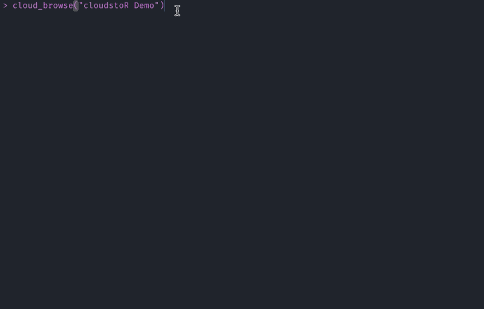

### View file or folder meta-data

You can view meta-data for a file or folder with `cloud_meta()`. This can be especially useful for checking if a file has been modified.

```r
cloud_meta(path = "cloudstoR Tests/mydata1.csv")
```

```
#>                                             file_name
#> 1 /plus/remote.php/webdav/cloudstoR Tests/mydata1.csv
#>                                  tag                 file_modified file_size
#> 1 "095d3de8121db760bef190fed3369278" Wed, 02 Mar 2022 22:27:13 GMT        35
```

### Updating credentials

If you need to delete your credentials (e.g., because you revoke your app password), you can restore them by calling `cloud_auth()` directly:

```r
cloud_auth(reset_keys = TRUE)
```

### Using an alternative WebDAV address

The default WebDAV address is `https://cloudstor.aarnet.edu.au/plus/remote.php/webdav/`. If your organisation uses a different address, you can set this globally at the top of your script:

```r
# Set the global WebDAV address
options(cloudstoR.cloud_address = "https:://my.webdav.address")
# Check the current value
getOption("cloudstoR.cloud_address")
```